# Submission 1 - Seasonal ARIMA

2024-07-30

| Nama : Ahmad Syahid Ibnu Syarif |
| --- |
| Satker : BPS Kota Dumai Provinsi Riau |

Overview: Pemodelan dilakukan menggunakan metode Seasonal ARIMA.

Pada Script ini terdapat beberapa package yang digunakan. Dapat diinstall sebelum menjalankan script

```r
##install.packages(c('ggplot2','tseries','forecast','DMwR',"here"))
```

set directory (bila perlu)

```r
library(here)
getwd()
```

```
## [1] "D:/LEARNING/INDAthon"
```

```r
setwd(here('dataset'))
## dapat disesuaikan, setwd() dengan here bisa digunakan jika diluar chunk
```

### Load Library

```r
library(ggplot2)
library(tseries)
library(forecast)
```

### Load Data

Load Data dan melihat struktur data

```r
pnmpg_tj<-read.csv("dataset/training_jumlah_penumpang_tj.csv",sep=";")
head(pnmpg_tj)
```

```
##   bulan tahun jumlah_penumpang
## 1     1  2015          8738599
## 2     2  2015          7630313
## 3     3  2015          9383835
## 4     4  2015          8832441
## 5     5  2015          9035420
## 6     6  2015          8692562
```

```r
str(pnmpg_tj)
```

```
## 'data.frame':    108 obs. of  3 variables:
##  $ bulan           : int  1 2 3 4 5 6 7 8 9 10 ...
##  $ tahun           : int  2015 2015 2015 2015 2015 2015 2015 2015 2015 2015 ...
##  $ jumlah_penumpang: int  8738599 7630313 9383835 8832441 9035420 8692562 7615995 8802642 8455633 8730480 ...
```

Load data Auxilary dan meliaht struktur data auxilary

```r
armd_tj<-read.csv("dataset/jumlah_armada_tj.csv",sep=";")
pnmpg_lrt<-read.csv("dataset/jumlah_penumpang_lrt.csv",sep=";")
pnmpg_mrt<-read.csv("dataset/jumlah_penumpang_mrt.csv",sep=";")
prjln_lrt<-read.csv("dataset/jumlah_perjalanan_lrt.csv",sep=";")
prjln_mrt<-read.csv("dataset/jumlah_perjalanan_mrt.csv",sep=";")

head(armd_tj)
```

```
##   bulan tahun jumlah_armada_tj
## 1     1  2023             3853
## 2     2  2023             3864
## 3     3  2023             3890
## 4     4  2023             3853
## 5     5  2023             3944
## 6     6  2023             3980
```

```r
head(pnmpg_lrt)
```

```
##   bulan tahun jumlah_penumpang
## 1     1  2023            72424
## 2     2  2023            76166
## 3     3  2023            82754
## 4     4  2023            72318
## 5     5  2023            78639
## 6     6  2023            84008
```

```r
head(pnmpg_mrt)
```

```
##   bulan tahun jumlah_penumpang
## 1     1  2023          2540315
## 2     2  2023          2378568
## 3     3  2023          2699585
## 4     4  2023          2065546
## 5     5  2023          2681876
## 6     6  2023          2709731
```

```r
head(prjln_lrt)
```

```
##   bulan tahun jumlah_perjalanan
## 1     1  2023              6190
## 2     2  2023              5980
## 3     3  2023              6200
## 4     4  2023              5998
## 5     5  2023              6198
## 6     6  2023              6098
```

```r
head(prjln_mrt)
```

```
##   bulan tahun jumlah_perjalanan
## 1     1  2023              8035
## 2     2  2023              7340
## 3     3  2023              8035
## 4     4  2023              7270
## 5     5  2023              8161
## 6     6  2023              7688
```

### Combine all data auxilary

Lima data auxilary yang tersedia memiliki dimensi yang sama. Untuk mempermudah melihat data auxilary, data tersebut digabung menjadi satu dataframe.

```r
data_aux<-armd_tj
data_aux['pnmpg_lrt']<-pnmpg_lrt['jumlah_penumpang']
data_aux['pnmpg_mrt']<-pnmpg_mrt['jumlah_penumpang']
data_aux['prjln_lrt']<-prjln_lrt['jumlah_perjalanan']
data_aux['prjln_mrt']<-prjln_mrt['jumlah_perjalanan']
head(data_aux)
```

```
##   bulan tahun jumlah_armada_tj pnmpg_lrt pnmpg_mrt prjln_lrt prjln_mrt
## 1     1  2023             3853     72424   2540315      6190      8035
## 2     2  2023             3864     76166   2378568      5980      7340
## 3     3  2023             3890     82754   2699585      6200      8035
## 4     4  2023             3853     72318   2065546      5998      7270
## 5     5  2023             3944     78639   2681876      6198      8161
## 6     6  2023             3980     84008   2709731      6098      7688
```

### Persiapan Pemodelan

Untuk analisis time series, perlu ada variabel penujuk waktu, yaitu variabel dengan format ‘date’.

```r
pnmpg_tj$date<-paste(pnmpg_tj$tahun,pnmpg_tj$bulan,"01",sep="-")
pnmpg_tj$date<-as.Date(as.character(pnmpg_tj$date),format="%Y-%m-%d")
str(pnmpg_tj)
```

```
## 'data.frame':    108 obs. of  4 variables:
##  $ bulan           : int  1 2 3 4 5 6 7 8 9 10 ...
##  $ tahun           : int  2015 2015 2015 2015 2015 2015 2015 2015 2015 2015 ...
##  $ jumlah_penumpang: int  8738599 7630313 9383835 8832441 9035420 8692562 7615995 8802642 8455633 8730480 ...
##  $ date            : Date, format: "2015-01-01" "2015-02-01" ...
```

Menampilkan plot line chart dari data jumlah penumpang Transjakarta

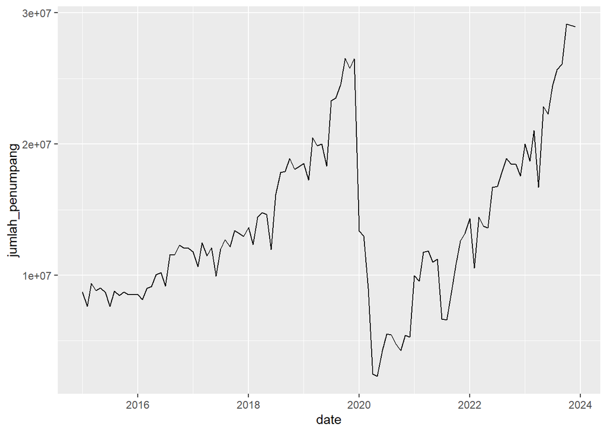

```r
ggplot(pnmpg_tj, aes(x=date, y=jumlah_penumpang)) +
  geom_line()
```

Secara visual terlihat bahwa jumlah penumpang Transjakarta mengalami penurunan drastispada masa Pandemi Covid-19 tahun 2020 hingga 2022. Secara visual juga terlihat bahwa data jumlah penumpang transjakarta tidak stasioner. Namun bisa jadi berupa musiman (seasonal).

### Uji Coba Modelling Seasonal ARIMA

Sebelum uji coba seasonal ARIMA, data harus dikonversi ke dalam format time series dengan function ts()

```r
tj_ts<-pnmpg_tj[,c("jumlah_penumpang","bulan","tahun")]
head(tj_ts)
```

```
##   jumlah_penumpang bulan tahun
## 1          8738599     1  2015
## 2          7630313     2  2015
## 3          9383835     3  2015
## 4          8832441     4  2015
## 5          9035420     5  2015
## 6          8692562     6  2015
```

```r
TJ.ts <- ts(tj_ts, frequency = 12, start = c(2015,1), end = c(2023,12))
class(TJ.ts)
```

```
## [1] "mts"    "ts"     "matrix" "array"
```

```r
head(TJ.ts)
```

```
##          jumlah_penumpang bulan tahun
## Jan 2015          8738599     1  2015
## Feb 2015          7630313     2  2015
## Mar 2015          9383835     3  2015
## Apr 2015          8832441     4  2015
## May 2015          9035420     5  2015
## Jun 2015          8692562     6  2015
```

Plot data time series

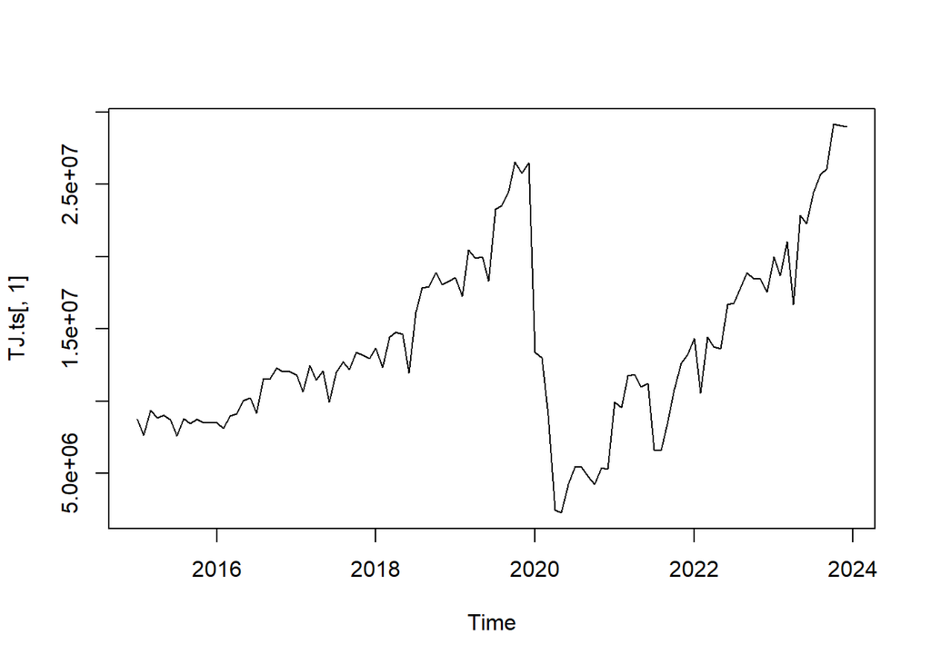

```r
plot.ts(TJ.ts[,1])
```

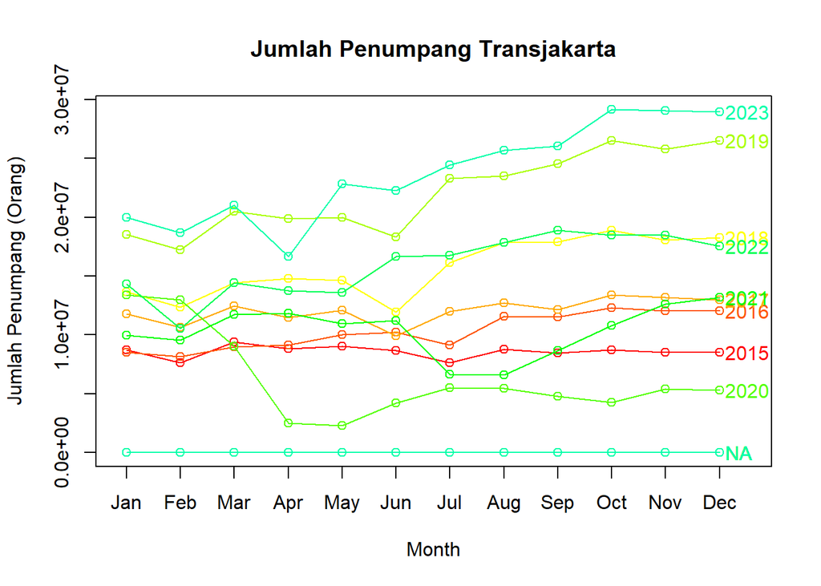

```r
seasonplot(TJ.ts,12,main="Jumlah Penumpang Transjakarta", ylab="Jumlah Penumpang (Orang)",year.labels = TRUE, col=rainbow(18))
```

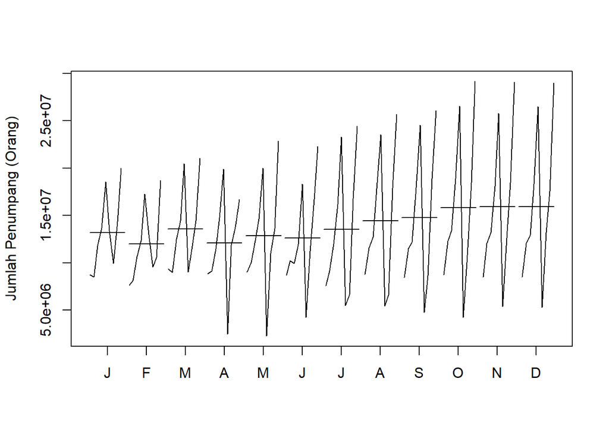

```r
monthplot(TJ.ts[,1],ylab="Jumlah Penumpang (Orang)")
```

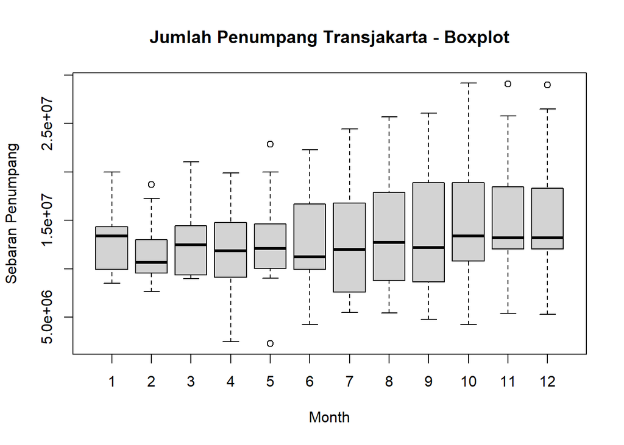

```r
boxplot(TJ.ts[,1] ~ cycle(TJ.ts[,1]), xlab = "Month", ylab = "Sebaran Penumpang", main = "Jumlah Penumpang Transjakarta - Boxplot")
```

Sekilas dari grafik terlihat bahwa data seasonal Penumpang Transjakarta tidak homogen. Maka perlu ditransformasi.

### Transformasi data

```r
log.TJ=log(TJ.ts[,1])
head(log.TJ)
```

```
##           Jan      Feb      Mar      Apr      May      Jun
## 2015 15.98326 15.84764 16.05450 15.99394 16.01666 15.97798
```

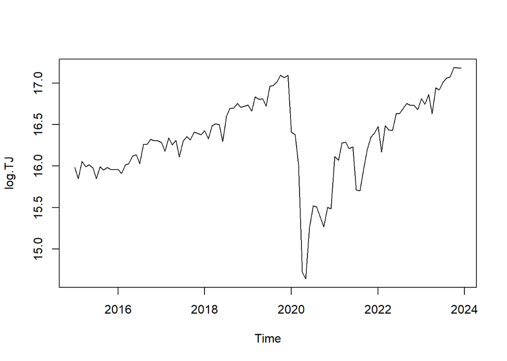

```r
plot.ts(log.TJ)
```

### Training Model

```r
model1 <- Arima(log.TJ,order=c(0,1,2),seasonal=c(0,1,1))
model2 <- Arima(log.TJ,order=c(1,1,1),seasonal=c(1,0,1))
model3 <- Arima(log.TJ,order=c(2,1,2),seasonal=c(1,1,2))
summary(model1)
```

```
## Series: log.TJ
## ARIMA(0,1,2)(0,1,1)[12]
##
## Coefficients:
##          ma1      ma2     sma1
##       0.1480  -0.1208  -1.0000
## s.e.  0.1027   0.1153   0.1432
##
## sigma^2 = 0.04344:  log likelihood = 2.59
## AIC=2.81   AICc=3.26   BIC=13.03
##
## Training set error measures:
##                       ME      RMSE        MAE        MPE      MAPE      MASE
## Training set 0.003544522 0.1923564 0.09932917 0.01410177 0.6187557 0.2036302
##                      ACF1
## Training set -0.002595847
```

```r
summary(model2)
```

```
## Series: log.TJ
## ARIMA(1,1,1)(1,0,1)[12]
##
## Coefficients:
##           ar1     ma1    sar1     sma1
##       -0.6966  0.7836  0.9905  -0.9653
## s.e.   0.2166  0.1822  0.0692   0.1351
##
## sigma^2 = 0.04467:  log likelihood = 15.26
## AIC=-20.52   AICc=-19.92   BIC=-7.15
##
## Training set error measures:
##                       ME     RMSE       MAE        MPE      MAPE      MASE
## Training set 0.009362212 0.206392 0.1170867 0.04832366 0.7292669 0.2400341
##                      ACF1
## Training set -0.007952702
```

```r
summary(model3)
```

```
## Series: log.TJ
## ARIMA(2,1,2)(1,1,2)[12]
##
## Coefficients:
```

```
##          ar1     ar2      ma1      ma2     sar1     sma1     sma2
##       0.2441  0.6199  -0.1520  -0.8480  -0.6623  -0.3478  -0.6522
## s.e.  0.1829  0.1803   0.1582   0.1535      NaN      NaN      NaN
##
## sigma^2 = 0.0424:  log likelihood = 3.95
## AIC=8.09   AICc=9.77   BIC=28.52
##
## Training set error measures:
##                       ME      RMSE       MAE          MPE      MAPE      MASE
## Training set 0.001741017 0.1858618 0.1001654 0.0005528099 0.6241065 0.2053445
##                    ACF1
## Training set 0.02352466
```

### Print Star Arima

Function untuk melihat model yang lebih optimal

```r
printstatarima <- function (x, digits = 4,se=TRUE){
       if (length(x$coef) > 0) {
         cat("\nCoefficients:\n")
         coef <- round(x$coef, digits = digits)
         if (se && nrow(x$var.coef)) {
           ses <- rep(0, length(coef))
           ses[x$mask] <- round(sqrt(diag(x$var.coef)), digits = digits)
           coef <- matrix(coef, 1, dimnames = list(NULL, names(coef)))
           coef <- rbind(coef, s.e. = ses)
           statt <- coef[1,]/ses
           pval  <- 2*pt(abs(statt), df=length(x$residuals)-1, lower.tail = FALSE)
           coef <- rbind(coef, t=round(statt,digits=digits),sign.= round(pval ,digits=digits))
           coef <- t(coef)
         }
         print.default(coef, print.gap = 2)
       }
     }
```

### Pengujian dari 3 model

```r
printstatarima(model1)
```

```
##
## Coefficients:
##                  s.e.        t   sign.
## ma1    0.1480  0.1027   1.4411  0.1525
## ma2   -0.1208  0.1153  -1.0477  0.2971
## sma1  -1.0000  0.1432  -6.9832  0.0000
```

```r
printstatarima(model2)
```

```
##
## Coefficients:
##                  s.e.        t   sign.
## ar1   -0.6966  0.2166  -3.2161  0.0017
## ma1    0.7836  0.1822   4.3008  0.0000
## sar1   0.9905  0.0692  14.3136  0.0000
## sma1  -0.9653  0.1351  -7.1451  0.0000
```

```r
printstatarima(model3)
```

```
##
## Coefficients:
```

```
##                  s.e.        t   sign.
## ar1    0.2441  0.1829   1.3346  0.1848
## ar2    0.6199  0.1803   3.4382  0.0008
## ma1   -0.1520  0.1582  -0.9608  0.3388
## ma2   -0.8480  0.1535  -5.5244  0.0000
## sar1  -0.6623     NaN      NaN     NaN
## sma1  -0.3478     NaN      NaN     NaN
## sma2  -0.6522     NaN      NaN     NaN
```

Dari hasil pengujian, model yang lebih optimal adalah model2. Terlihat bahwa pada model2, semua dugaan parameternya berpengaruh nyata.

### Forecasting

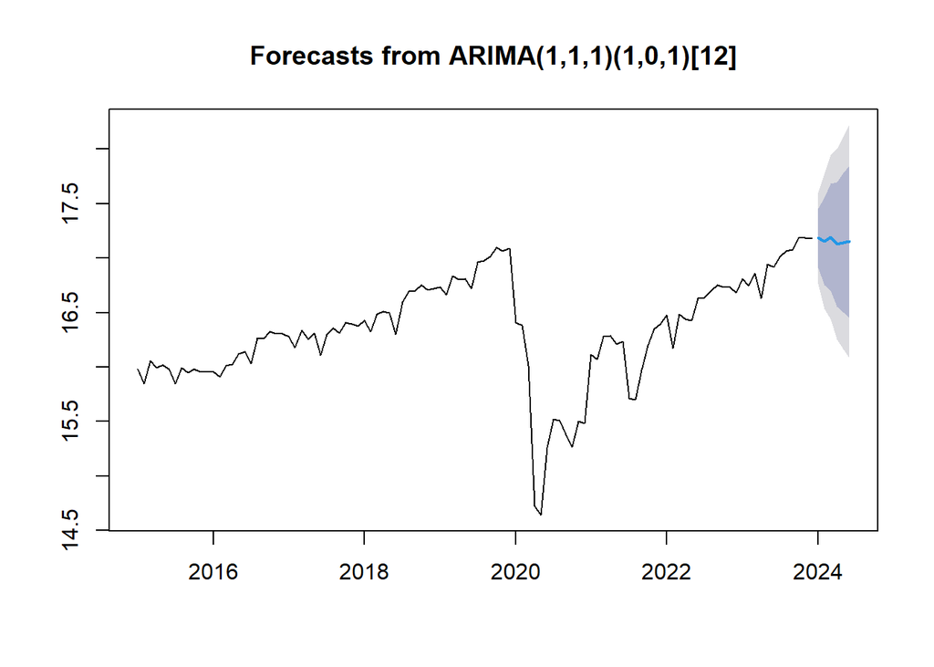